# islamsamia-assignment02-nb

```python
# import libraries
import matplotlib.pyplot as plt
# import our custom code as a module
import code02 as a2
# force code reload if this cell is run
# this allows to modify the code externally and have the changes reflected here
from importlib import reload
reload(a2)

# tell the notebook to plot the figures inside the notebook
%matplotlib inline
```

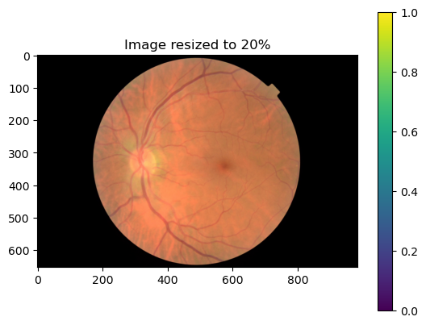

```python
# load image file and resize to 20%
im = a2.Image_process('data/68_left.jpeg')
im_resz = im.load_image()
# display resized image
im.show_im(im_resz, 'Image resized to 20%')
```

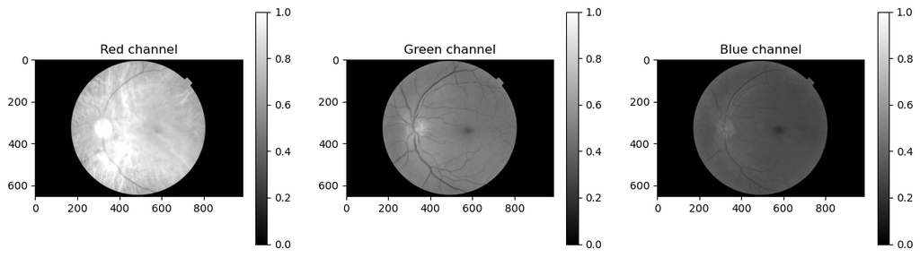

```python
# separate red, green and blue channels
ch_dict = {'Red channel': 0, 'Green channel': 1, 'Blue channel': 2}
len_dict = len(ch_dict)
plt.figure(figsize = (15, 4))
for i in ch_dict:
    plt.subplot(1, len_dict, ch_dict[i]+1)
    im.show_im(im_resz[:,:,ch_dict[i]], i, grayscale=1, newFig=False, immediateShow=False)
plt.show()
```

```python
# convert image to grayscale
imG = im.convrgb2gray(im_resz)
# find brightest area of image
# NOTE: the numpy unravel function returns the row and column values. These need to
# be mapped to corresponding x, y values where the row values are along the y axis
# and col values are along the x axis. So, the x, y coordinates are col, row values,
# respectively
ind_row, ind_col = im.brtAreaImg(imG)
print('X, Y coordinates of brightest area in image: ({0}, {1})'.format(ind_col, ind_row))
print('Row, Col indices of brightest area in image: ({0}, {1})'.format(ind_row, ind_col))
```

```
X, Y coordinates of brightest area in image: (357, 313)
Row, Col indices of brightest area in image: (313, 357)
```

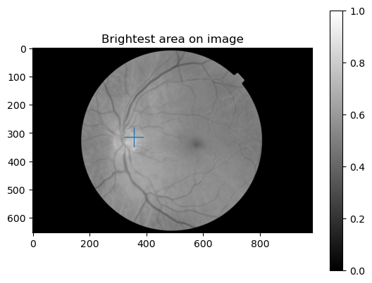

```python
# show brightest point on image
# NOTE: the numpy unravel function returns the row and column values. These need to
# be mapped to corresponding x, y values where the row values are along the y axis
# and col values are along the x axis. So, the x, y coordinates are col, row values,
# respectively
im.show_im(imG, 'Brightest area on image', grayscale=1, newFig=False, immediateShow=False)
plt.plot(ind_col, ind_row, '+', ms=20)
plt.show()
```

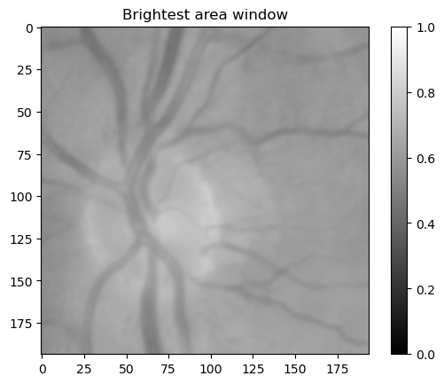

```python
# plot a window centered on the brightest area and adjust size of window to be 30% of image height
imG_wind = im.windDim(imG, 0.3, ind_row, ind_col)
im.show_im(imG_wind, 'Brightest area window', grayscale=1)
```

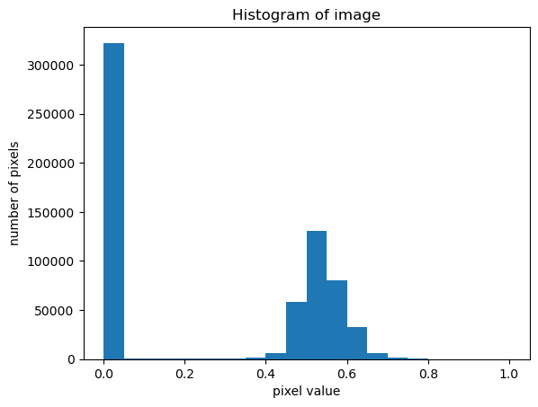

```python
# visualize histogram
img_flat = im.flatImg(imG)
im.show_hist(img_flat, 'Histogram of image', 'pixel value', 'number of pixels')
```

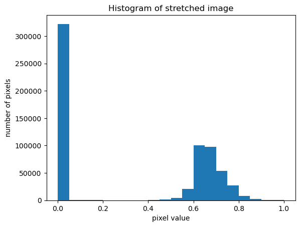

```python
# visualize histogram for stretched image
img_stretch_flat = im.histStr(img_flat, 0, 1)
im.show_hist(img_stretch_flat, 'Histogram of stretched image', 'pixel value', 'number of pixels')
```

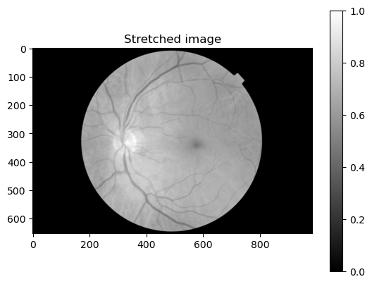

```python
# reshape image
img_stretch_array = img_stretch_flat.reshape(imG.shape)
# display resized image
im.show_im(img_stretch_array, 'Stretched image', grayscale=1)
```

```python
# find otsu threshold
thresh = im.findOtsuThresh(imG)
print('Threshold value is: ', thresh)
```

```
Threshold value is:  0.26820058593749996
```

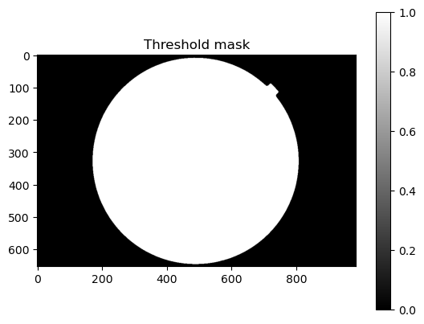

```python
# create boolean mask based on otsu threshold value
bool_mask = im.boolMask(imG, thresh)
im.show_im(bool_mask, 'Threshold mask', grayscale=1)
```

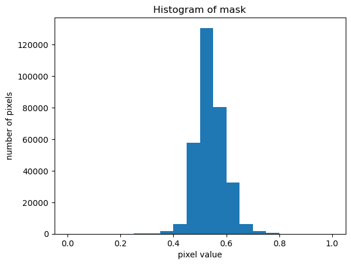

```python
# extract pixels inside mask. This will be a 1D vector because
# once extracted, masked image does not maintain original image
# dimension. It is simply a range of values within the image.
img_mask = im.extractBoolMask(bool_mask, imG)
im.show_hist(img_mask, 'Histogram of mask', 'pixel value', 'number of pixels')
```

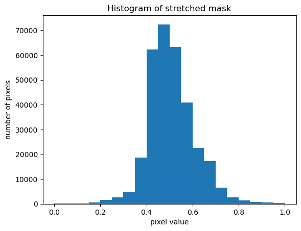

```python
# histogram stretching on the mask
img_mask_stretch_flat = im.histStr(img_mask, 0, 1)
im.show_hist(img_mask_stretch_flat, 'Histogram of stretched mask', 'pixel value', 'number of pixels')
```

Comparing with previous histogram stretching approach, where entire image was stretched, we don't see a bimodal distribution anymore. In the previous image, the black color on the corners was stretched without any effect because the minimum value of the image and the possible minimum value from the range of values canceled each other out. The presence of this outlier limited the stretching of the range of the intensity values. When we applied histogram stretching on the extracted image (i.e. the fundus part only), we see better use of the possible values, from 0 to 1.

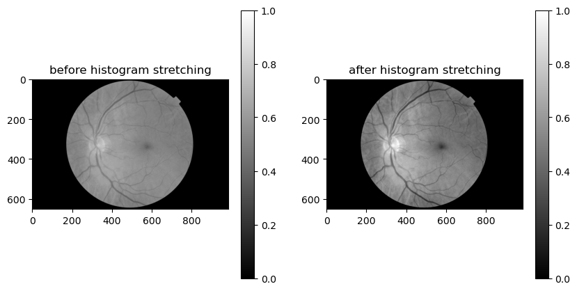

```python
# display image before and after histogram stretching on mask pixels
img2 = im.extractStrPix(imG, img_mask_stretch_flat, bool_mask)
plt.figure(figsize = (10, 5))
plt.subplot(1, 2, 1)
im.show_im(imG, 'before histogram stretching', grayscale=1, newFig=False, immediateShow=False)
plt.subplot(1, 2, 2)
im.show_im(img2, 'after histogram stretching', grayscale=1, newFig=False, immediateShow=False)
plt.show()
```

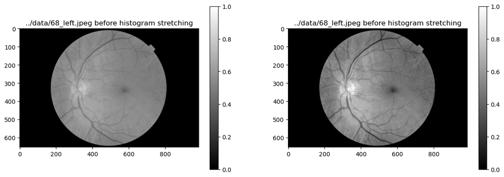

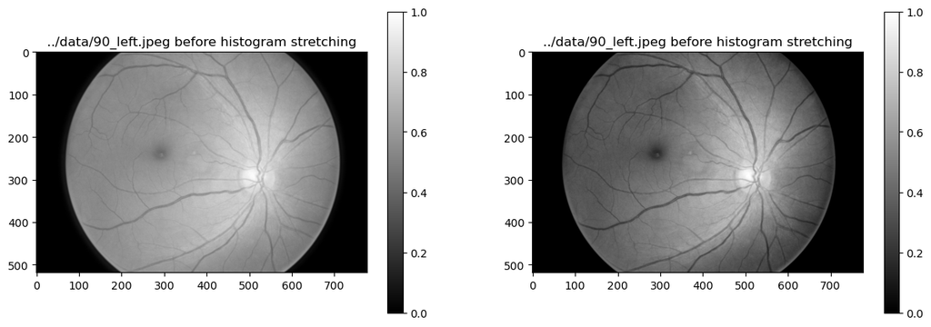

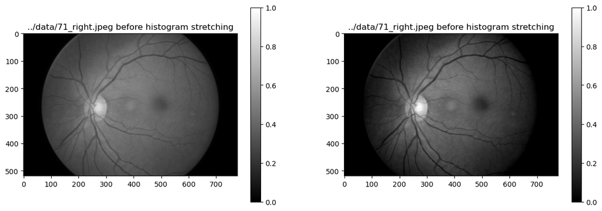

```python
# perform the previous mask detection and histogram stretching, given a file name
# first get a list of files
im_dir = a2.Image_directory('data')
img_file_list = im_dir.get_file_list()
# loop through each image to perform masking and histogram stretching
for i in img_file_list:
    im_proc = a2.Image_process(i)
    orig_img, stretched_img = im_proc.mask_det_hist_str()
    plt.figure(figsize = (15, 5))
    plt.subplot(1, 2, 1)
    title_before = i+' before histogram stretching'
    im_proc.show_im(orig_img, title_before, grayscale=1, newFig=False, immediateShow=False)
    plt.subplot(1, 2, 2)
    title_after = i+' before histogram stretching'
    im_proc.show_im(stretched_img, title_after, grayscale=1, newFig=False, immediateShow=False)
plt.show()
```

Bonus Question: Did the histogram stretching procedure does not work perfectly for all three images. What went wrong in one of them? From the above images, it seems to me that histogram stretching has limited advantage when it comes to mostly light or mostly dark image. If we are trying to locate a point on the image where most values are close to the possible intensity range limits, this method will not work well. Since in retina images we want to find the brightest area of the image so that we can estimate the rough location of the optic nerve, this method will not produce the best result for a mostly light image, like we see for 90_left.jpeg. Consequently, if we were trying to find a dark area on the image, histogram stretching would not be best suited for a mostly dark image, as we can see from 71_right.jpeg.